```python
import pip
pip.main(['install', 'pandas'])
pip.main(['install', 'matplotlib'])
pip.main(['install', 'seaborn'])
pip.main(['install', 'scikit-learn'])
```

# CHARGEMENT DES BIBLIOTHEQUES

```python
import pandas as pd
import matplotlib.pyplot as plt
import numpy as np
import seaborn as sns
import missingno as msno
from sklearn.experimental import enable_iterative_imputer
from sklearn.impute import MissingIndicator, KNNImputer,SimpleImputer
from sklearn.impute import IterativeImputer
from sklearn.linear_model import LogisticRegression
from sklearn.model_selection import train_test_split
from sklearn.datasets import make_classification
from sklearn.metrics import roc_curve, auc
from sklearn.metrics import accuracy_score, classification_report, confusion_matrix
from sklearn.preprocessing import StandardScaler
from sklearn.preprocessing import OneHotEncoder
from sklearn.preprocessing import LabelEncoder
```

Chargement du jeu de données "LIGNES_TICKET_V4"

```python
dataset_path = "C:\\Users\\belga\\OneDrive\\Bureau\\EMBA Big Data\\Module Datascience\\Projet Data Science S2 2024\\LIGNES_TICKET_V4.csv"
LGNES_TICKETS = pd.read_csv(dataset_path, sep='|', low_memory=False)
print(LGNES_TICKETS.shape)
print(list(LGNES_TICKETS.columns))
```

```
(34105705, 7)
['IDTICKET', 'NUMLIGNETICKET', 'IDARTICLE', 'QUANTITE', 'MONTANTREMISE', 'TOTAL', 'MARGESORTIE']
```

La ligne de code ci-dessous nous permet de voir le détail des colonnes de notre jeu de données ainsi que le type de données (chaîne de caractères, numérique)

```python
print(LGNES_TICKETS.info())
```

```
<class 'pandas.core.frame.DataFrame'>
RangeIndex: 34105705 entries, 0 to 34105704
Data columns (total 7 columns):
 #   Column          Dtype
---  ------          -----
 0   IDTICKET        int64
 1   NUMLIGNETICKET  int64
 2   IDARTICLE       object
 3   QUANTITE        object
 4   MONTANTREMISE   object
 5   TOTAL           object
 6   MARGESORTIE     object
dtypes: int64(2), object(5)
memory usage: 1.8+ GB
None
```

Aperçu du jeu de données.

```python
LGNES_TICKETS.head(10)
```

|  | IDTICKET | NUMLIGNETICKET | IDARTICLE | QUANTITE | MONTANTREMISE | TOTAL | MARGESORTIE |
| --- | --- | --- | --- | --- | --- | --- | --- |
| 0 | 190400316260 | 2 | 246208 | 1,000 | ,000 | 4,96 | 2,37 |
| 1 | 190400316262 | 2 | 33725 | 1,000 | ,000 | 8,25 | 3,63 |
| 2 | 190400316262 | 3 | 634497 | 1,000 | ,000 | 5,79 | 3,63 |
| 3 | 190400316262 | 1 | 257613 | 1,000 | ,000 | 18,29 | 6,21 |
| 4 | 190400316263 | 1 | 257627 | 1,000 | ,000 | 49,92 | 10,42 |
| 5 | 190400316265 | 1 | 320054 | 1,000 | ,000 | 6,42 | ,67 |
| 6 | 190400316265 | 3 | 835984 | 1,000 | ,000 | 37,42 | 13,78 |
| 7 | 190400316265 | 2 | 290491 | 1,000 | ,000 | 5,42 | 4,22 |
| 8 | 190400316270 | 6 | 932088 | 1,000 | ,000 | 6,25 | 6,25 |
| 9 | 190400316270 | 4 | 165207 | 3,000 | 2,250 | 20,22 | 10,29 |

```python
LGNES_TICKETS.tail(10)
```

|  | IDTICKET | NUMLIGNETICKET | IDARTICLE | QUANTITE | MONTANTREMISE | TOTAL | MARGESORTIE |
| --- | --- | --- | --- | --- | --- | --- | --- |
| 34105695 | 340200383182 | 4 | 36771 | 1 | 0 | 7,46 | 5,81 |
| 34105696 | 340200383182 | 5 | 179749 | 2 | 0 | 14,92 | 8,78 |
| 34105697 | 340200383182 | 6 | 699430 | 3 | 0 | 19,87 | 13,75 |
| 34105698 | 340200383182 | 7 | 784813 | 1 | 0 | 8,29 | 5,32 |
| 34105699 | 340200383203 | 1 | 257645 | 1 | 0 | 4,69 | 1,84 |
| 34105700 | 340200383203 | 2 | 257643 | 1 | 0 | 4,69 | 1,83 |
| 34105701 | 340200383203 | 3 | 50170 | 1 | 0 | 3,18 | 1 |
| 34105702 | 340200383203 | 4 | 349345 | 1 | 0 | 3,46 | 1,13 |
| 34105703 | 340200383203 | 5 | 250580 | 2 | 0 | 6,8 | 2,18 |
| 34105704 | 340200383217 | 1 | 816313 | 20 | 1,818 | 1,82 | 1,42 |

Afin d'exploiter de façon optimale les informations, nous allons convetir les l'ID TICKET et le NUM LIGNE TICKET en caractère. A l'inverse, nous devons convertir les quantités, les montants, les totaux et les marges en valeur numérique.

```python
LGNES_TICKETS['IDTICKET'] = LGNES_TICKETS['IDTICKET'].astype(str)
LGNES_TICKETS['NUMLIGNETICKET'] = LGNES_TICKETS['NUMLIGNETICKET'].astype(str)
```

```python
LGNES_TICKETS["QUANTITE"]=LGNES_TICKETS['QUANTITE'].str.replace(',', '.').astype(float)
```

```python
LGNES_TICKETS["TOTAL"]=LGNES_TICKETS['TOTAL'].str.replace(',', '.').astype(float)
```

```python
LGNES_TICKETS["MONTANTREMISE"]=LGNES_TICKETS['MONTANTREMISE'].str.replace(',', '.').astype(float)
```

```python
LGNES_TICKETS["MARGESORTIE"]=LGNES_TICKETS['MARGESORTIE'].str.replace(',', '.').astype(float)
```

Vérification du traitement.

```python
print(LGNES_TICKETS.info())
```

```
<class 'pandas.core.frame.DataFrame'>
RangeIndex: 34105705 entries, 0 to 34105704
Data columns (total 7 columns):
 #   Column          Dtype
---  ------          -----
 0   IDTICKET        object
 1   NUMLIGNETICKET  object
 2   IDARTICLE       object
 3   QUANTITE        float64
 4   MONTANTREMISE   float64
 5   TOTAL           float64
 6   MARGESORTIE     float64
dtypes: float64(4), object(3)
memory usage: 1.8+ GB
None
```

Identification de la valeur minimale.

```python
LGNES_TICKETS['QUANTITE'].min()
```

```
-155.0
```

Affichage du dataframe

```python
LGNES_TICKETS
```

|  | IDTICKET | NUMLIGNETICKET | IDARTICLE | QUANTITE | MONTANTREMISE | TOTAL | MARGESORTIE |
| --- | --- | --- | --- | --- | --- | --- | --- |
| 0 | 190400316260 | 2 | 246208 | 1.0 | 0.000 | 4.96 | 2.37 |
| 1 | 190400316262 | 2 | 33725 | 1.0 | 0.000 | 8.25 | 3.63 |
| 2 | 190400316262 | 3 | 634497 | 1.0 | 0.000 | 5.79 | 3.63 |
| 3 | 190400316262 | 1 | 257613 | 1.0 | 0.000 | 18.29 | 6.21 |
| 4 | 190400316263 | 1 | 257627 | 1.0 | 0.000 | 49.92 | 10.42 |
| ... | ... | ... | ... | ... | ... | ... | ... |
| 34105700 | 340200383203 | 2 | 257643 | 1.0 | 0.000 | 4.69 | 1.83 |
| 34105701 | 340200383203 | 3 | 50170 | 1.0 | 0.000 | 3.18 | 1.00 |
| 34105702 | 340200383203 | 4 | 349345 | 1.0 | 0.000 | 3.46 | 1.13 |
| 34105703 | 340200383203 | 5 | 250580 | 2.0 | 0.000 | 6.80 | 2.18 |
| 34105704 | 340200383217 | 1 | 816313 | 20.0 | 1.818 | 1.82 | 1.42 |

34105705 rows × 7 columns

Création d'une nouvelle variable "top retour".

```python
# Création de la variable 'TOP_RETOUR' basée sur la colonne 'QUANTITE'
LGNES_TICKETS['TOP_RETOUR'] = np.where(LGNES_TICKETS['QUANTITE'] < 0, 1, 0)

# Afficher le DataFrame avec la nouvelle variable 'TOP_RETOUR'
print(LGNES_TICKETS)
```

```
              IDTICKET NUMLIGNETICKET IDARTICLE  QUANTITE  MONTANTREMISE  \
0         190400316260              2    246208       1.0          0.000
1         190400316262              2     33725       1.0          0.000
2         190400316262              3    634497       1.0          0.000
3         190400316262              1    257613       1.0          0.000
4         190400316263              1    257627       1.0          0.000
...                ...            ...       ...       ...            ...
34105700  340200383203              2    257643       1.0          0.000
34105701  340200383203              3     50170       1.0          0.000
34105702  340200383203              4    349345       1.0          0.000
34105703  340200383203              5    250580       2.0          0.000
34105704  340200383217              1    816313      20.0          1.818

          TOTAL  MARGESORTIE  TOP_RETOUR
0          4.96         2.37           0
1          8.25         3.63           0
2          5.79         3.63           0
3         18.29         6.21           0
4         49.92        10.42           0
...         ...          ...         ...
34105700   4.69         1.83           0
34105701   3.18         1.00           0
34105702   3.46         1.13           0
34105703   6.80         2.18           0
34105704   1.82         1.42           0

[34105705 rows x 8 columns]
```

```python
LGNES_TICKETS['TOP_RETOUR'].value_counts()
```

```
TOP_RETOUR
0    34003892
1      101813
Name: count, dtype: int64
```

Création d'une nouvelle variable "solde qté".

```python
# Calcul de la nouvelle variable 'SOLDE_QTE' en regroupant par 'IDTICKET'
data_grouped = LGNES_TICKETS.groupby('IDTICKET').agg({
    'TOP_RETOUR': 'max',
    'QUANTITE': 'sum'
})
```

```python
data_grouped
```

| IDTICKET | TOP_RETOUR | QUANTITE |
| --- | --- | --- |
| 1000100553129 | 0 | 7.365 |
| 1000100553131 | 0 | 5.976 |
| 1000100553133 | 0 | 9.309 |
| 1000100553134 | 1 | 1.000 |
| 1000100553139 | 0 | 2.000 |
| ... | ... | ... |
| 990600196600 | 0 | 16.737 |
| 990600196602 | 0 | 36.090 |
| 990600196607 | 0 | 12.000 |
| 990600196608 | 0 | 1.000 |
| 990600196609 | 0 | 7.000 |

6713822 rows × 2 columns

```python
columns=['MONTANTREMISE', 'TOTAL', 'MARGESORTIE']
data7=LGNES_TICKETS[columns]
data7[columns].shape
```

```
(34105705, 3)
```

Descriptif de notre dataframe.

```python
data7.describe()
```

|  | MONTANTREMISE | TOTAL | MARGESORTIE |
| --- | --- | --- | --- |
| count | 3.410570e+07 | 3.410570e+07 | 3.410570e+07 |
| mean | 9.912670e-01 | 9.937605e+00 | 4.224984e+00 |
| std | 6.086740e+00 | 2.426155e+01 | 1.166608e+01 |
| min | -4.269420e+02 | -1.500000e+04 | -1.500000e+04 |
| 25% | 0.000000e+00 | 2.820000e+00 | 9.900000e-01 |
| 50% | 0.000000e+00 | 5.210000e+00 | 2.260000e+00 |
| 75% | 4.730000e-01 | 1.050000e+01 | 5.210000e+00 |
| max | 1.316667e+04 | 1.500000e+04 | 1.500000e+04 |

```python
data7[columns].max()
```

```
MONTANTREMISE    13166.667
TOTAL            15000.000
MARGESORTIE      15000.000
dtype: float64
```

Il convient à présent de vérifier la présence de valeur aberrantes.

```python
def boxplot(LGNES_TICKETS):
    plt.figure(figsize=(16, 6))
    sns.boxplot(data=data7)
    plt.grid()
```

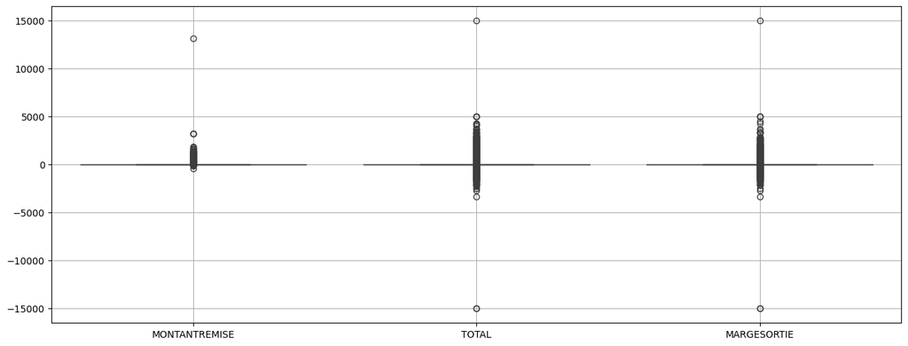

```python
boxplot(data7)
```

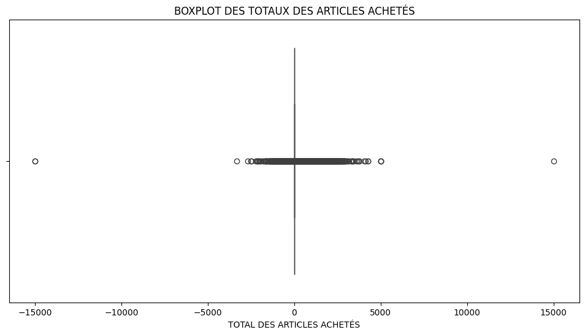

```python
# Visualiser les outliers en utilisant un boxplot avec Seaborn
plt.figure(figsize=(12, 6))
sns.boxplot(data=data7, x='TOTAL')
plt.xlabel('TOTAL DES ARTICLES ACHETÉS')
plt.title("BOXPLOT DES TOTAUX DES ARTICLES ACHETÉS")
plt.show()
```

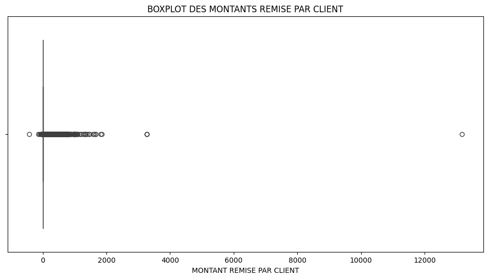

```python
# Visualiser les outliers en utilisant un boxplot avec Seaborn
plt.figure(figsize=(12, 6))
sns.boxplot(data=data7, x='MONTANTREMISE')
plt.xlabel('MONTANT REMISE PAR CLIENT')
plt.title("BOXPLOT DES MONTANTS REMISE PAR CLIENT")
plt.show()
```

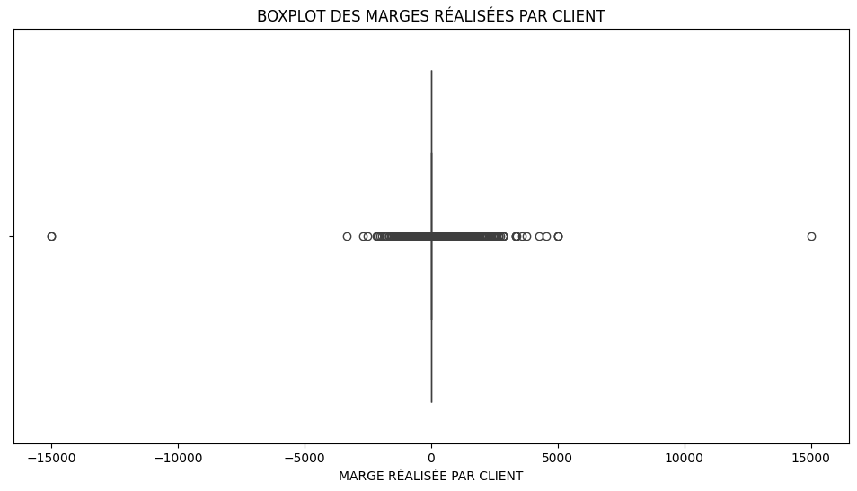

```python
# Visualiser les outliers en utilisant un boxplot avec Seaborn
plt.figure(figsize=(12, 6))
sns.boxplot(data=data7, x='MARGESORTIE')
plt.xlabel('MARGE RÉALISÉE PAR CLIENT')
plt.title("BOXPLOT DES MARGES RÉALISÉES PAR CLIENT")
plt.show()
```

Traitement des valeurs aberantes identifiées.

```python
from pandas.api.types import is_numeric_dtype
columns=['MONTANTREMISE', 'TOTAL', 'MARGESORTIE']
data7=LGNES_TICKETS[columns]
# Fonction pour détecter les outliers en utilisant l'IQR
def detect_outliers_iqr(data4, columns):
    Q1 = data7[columns].quantile(0.25)
    Q3 = data7[columns].quantile(0.75)
    IQR = Q3 - Q1
    lower_bound = Q1 - 1.5 * IQR
    upper_bound = Q3 + 1.5 * IQR
    outliers = data7[(data4[columns] < lower_bound) | (data4[columns] > upper_bound)]
    return outliers

# Boucler à travers les colonnes numériques pour détecter les outliers
for col in data7.columns:
    if is_numeric_dtype(LGNES_TICKETS[col]):
        outliers = detect_outliers_iqr(data7, col)
        if len(outliers) > 0:
            print(f"Outliers détectés dans la colonne '{col}':")
            print(outliers)
```

```
Outliers détectés dans la colonne 'MONTANTREMISE':
          MONTANTREMISE   TOTAL  MARGESORTIE
9                 2.250   20.22        10.29
10                1.483   13.39         7.09
13                1.208   10.87         5.74
44               32.500  132.50        38.38
45               10.836   18.16         3.96
...                 ...     ...          ...
34105666         12.500   57.92        28.42
34105672          2.458    0.83        -0.68
34105682          6.545    6.55         5.11
34105684          4.545   18.14         7.19
34105704          1.818    1.82         1.42

[5073982 rows x 3 columns]
```

[output cut: 30 more lines]

```python
from pandas.api.types import is_numeric_dtype
columns=['MONTANTREMISE', 'TOTAL', 'MARGESORTIE']
data7=LGNES_TICKETS[columns]
# Fonction pour imputer les outliers
def impute_outliers(data7, columns):
    Q1 = np.percentile(data7[columns],25)
    Q3 = np.percentile(data7[columns],75)
    IQR = Q3 - Q1
    lower_bound = Q1 - 1.5 * IQR
    upper_bound = Q3 + 1.5 * IQR
    data7.loc[data7[columns] < lower_bound, columns] = lower_bound
    data7.loc[data7[columns] > upper_bound,columns]=upper_bound
for columns in columns:
    impute_outliers(data7,columns)
```

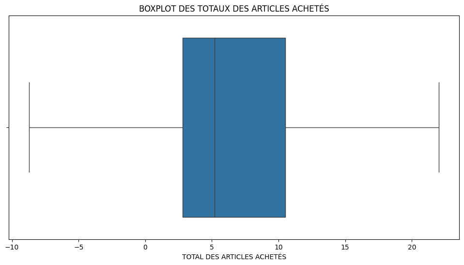

```python
# Visualiser les outliers en utilisant un boxplot avec Seaborn
plt.figure(figsize=(12, 6))
sns.boxplot(data=data7, x='TOTAL')
plt.xlabel('TOTAL DES ARTICLES ACHETÉS')
plt.title("BOXPLOT DES TOTAUX DES ARTICLES ACHETÉS")
plt.show()
```

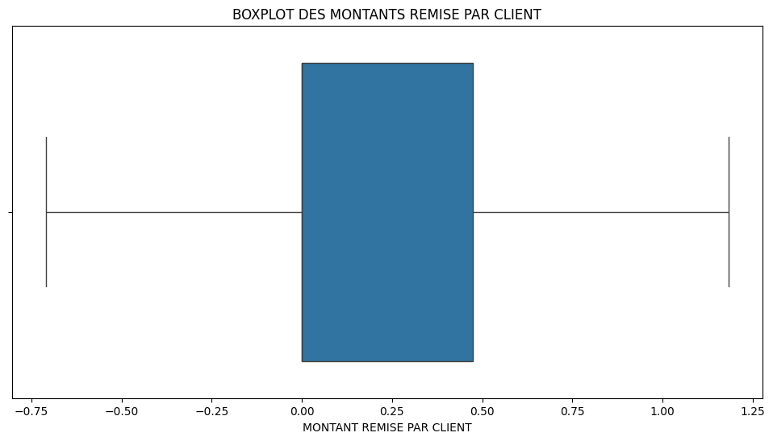

```python
# Visualiser les outliers en utilisant un boxplot avec Seaborn
plt.figure(figsize=(12, 6))
sns.boxplot(data=data7, x='MONTANTREMISE')
plt.xlabel('MONTANT REMISE PAR CLIENT')
plt.title("BOXPLOT DES MONTANTS REMISE PAR CLIENT")
plt.show()
```

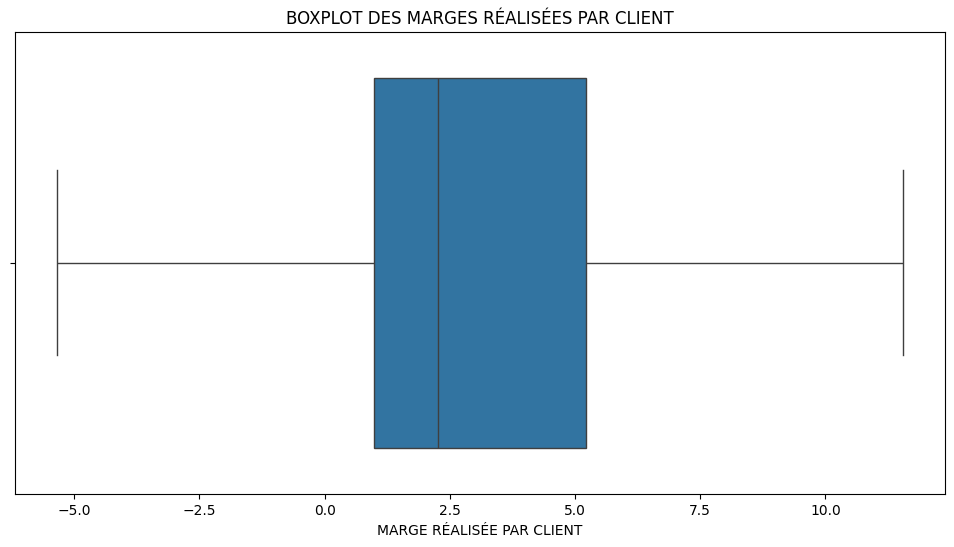

```python
# Visualiser les outliers en utilisant un boxplot avec Seaborn
plt.figure(figsize=(12, 6))
sns.boxplot(data=data7, x='MARGESORTIE')
plt.xlabel('MARGE RÉALISÉE PAR CLIENT')
plt.title("BOXPLOT DES MARGES RÉALISÉES PAR CLIENT")
plt.show()
```

```python
# Appel à la fonction detect_outliers_iqr() pour obtenir les bornes lower_bound et upper_bound
outliers = detect_outliers_iqr(data7, columns)
lower_bound = outliers[columns].min()
upper_bound = outliers[columns].max()

# Remplacement des outliers par les bornes
data7.loc[:, columns] = data7[columns].clip(lower=lower_bound, upper=upper_bound)

# Afficher le DataFrame avec les outliers corrigés
print(data7)
```

```
          MONTANTREMISE  TOTAL  MARGESORTIE
0                0.0000   4.96         2.37
1                0.0000   8.25         3.63
2                0.0000   5.79         3.63
3                0.0000  18.29         6.21
4                0.0000  22.02        10.42
...                 ...    ...          ...
34105700         0.0000   4.69         1.83
34105701         0.0000   3.18         1.00
34105702         0.0000   3.46         1.13
34105703         0.0000   6.80         2.18
34105704         1.1825   1.82         1.42

[34105705 rows x 3 columns]
```

Descriptif de notre dataframe.

```python
data7.describe()
```

|  | MONTANTREMISE | TOTAL | MARGESORTIE |
| --- | --- | --- | --- |
| count | 3.410570e+07 | 3.410570e+07 | 3.410570e+07 |
| mean | 2.790697e-01 | 7.553460e+00 | 3.461244e+00 |
| std | 4.499037e-01 | 6.522058e+00 | 3.454784e+00 |
| min | -7.095000e-01 | -8.700000e+00 | -5.340000e+00 |
| 25% | 0.000000e+00 | 2.820000e+00 | 9.900000e-01 |
| 50% | 0.000000e+00 | 5.210000e+00 | 2.260000e+00 |
| 75% | 4.730000e-01 | 1.050000e+01 | 5.210000e+00 |
| max | 1.182500e+00 | 2.202000e+01 | 1.154000e+01 |

La ligne de code ci-dessous nous permet d'identifier les valeurs en doublons qui conviendra de traiter.

```python
print(LGNES_TICKETS.duplicated().sum())
LGNES_TICKETS = LGNES_TICKETS.drop_duplicates()
```

```
130
```

Nous allons désormais procéder au traitement de ces doublons.

```python
LGNES_TICKETS.drop_duplicates(keep='first', inplace=True)
```

Code de vérification.

```python
print(LGNES_TICKETS.duplicated().sum())
```

```
0
```

Nous procédons également à la vérification de présence ou non de valeurs manquantes (aucune valeur détectée).

```python
LGNES_TICKETS.isnull().sum()
```

```
IDTICKET          0
NUMLIGNETICKET    0
IDARTICLE         0
QUANTITE          0
MONTANTREMISE     0
TOTAL             0
MARGESORTIE       0
TOP_RETOUR        0
dtype: int64
```

Enregistrement de notre dataframe pour faciliter sa réutilisation, dans un autre notebook, sans avoir à tout éxécuter.

```python
LIGNES_TICKET = "C:\\Users\\belga\\OneDrive\\Bureau\\EMBA Big Data\\Module Datascience\\Projet Data Science S2 2024\\TICKETS_NET.pkl"
LGNES_TICKETS.to_pickle(LIGNES_TICKET)
```